# MNIST with Naive Bayes

#### Here we see the probablity mapped images for each class for a particular test instance which was correctly classified

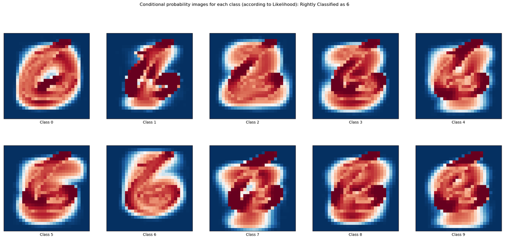

```python
likeli = nb[1]
likli = likeli[9999]
matplot.subplots(2,5, figsize=(24,10))
for i in range(10):
    l1 = matplot.subplot(2, 5, i + 1)
    l1.imshow(likli[i].reshape(28, 28), interpolation='nearest',cmap=matplot.cm.RdBu)
    l1.set_xticks(())
    l1.set_yticks(())
    l1.set_xlabel('Class %i' % i)
matplot.suptitle('Conditional probability images for each class (according to Likelihood): Rightly Classified as 6')
matplot.show()
```

#### Here we see the probablity mapped images for each class for a particular test instance which was incorrectly classified

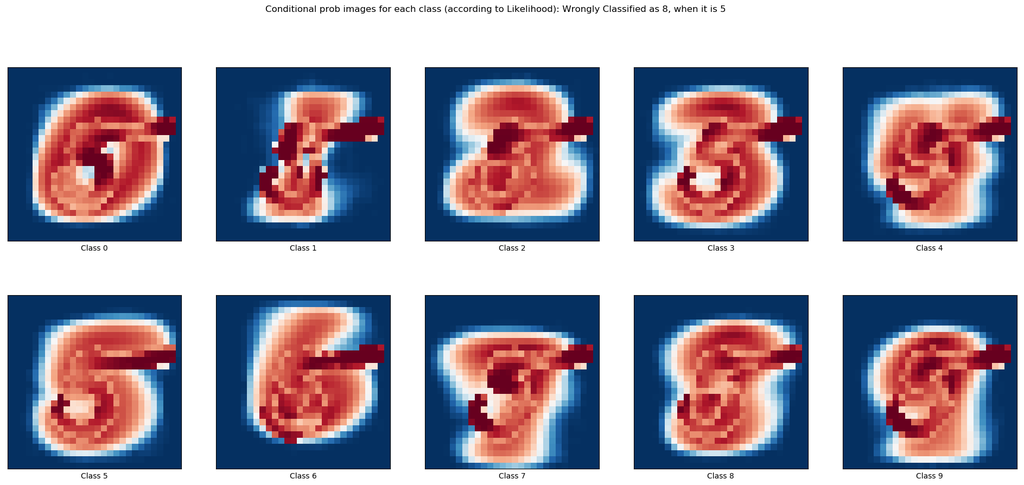

```python
likli = likeli[9998]
matplot.subplots(2,5, figsize=(24,10))
for i in range(10):
    l1 = matplot.subplot(2, 5, i + 1)
    l1.imshow(likli[i].reshape(28, 28), interpolation='nearest',cmap=matplot.cm.RdBu)
    l1.set_xticks(())
    l1.set_yticks(())
    l1.set_xlabel('Class %i' % i)
matplot.suptitle('Conditional prob images for each class (according to Likelihood): Wrongly Classified as 8, when it is 5')
matplot.show()
```

We can see the underlying numbers of the class and the test number overlayed on top to get the probabilities, all these class probabilties are blurred as we used guassian. I would say that Naive Bayes puts the number on top of the class to see if there is a match.

### In conclusion:

Naive bayes gives pretty low accuracy as compared to kNN (from the last assignment). The reason being, it consideres all the probablities as independent of each other (hence- naive). We can also see the probablity images of the samples, that it is difficult to differenciate between the classes with naive bayes probability